# 1 ggPlot2

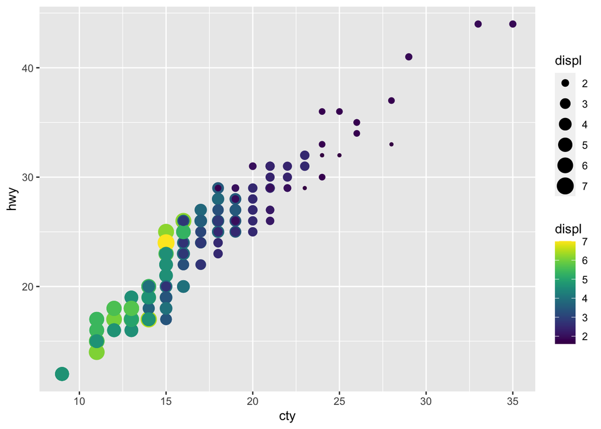

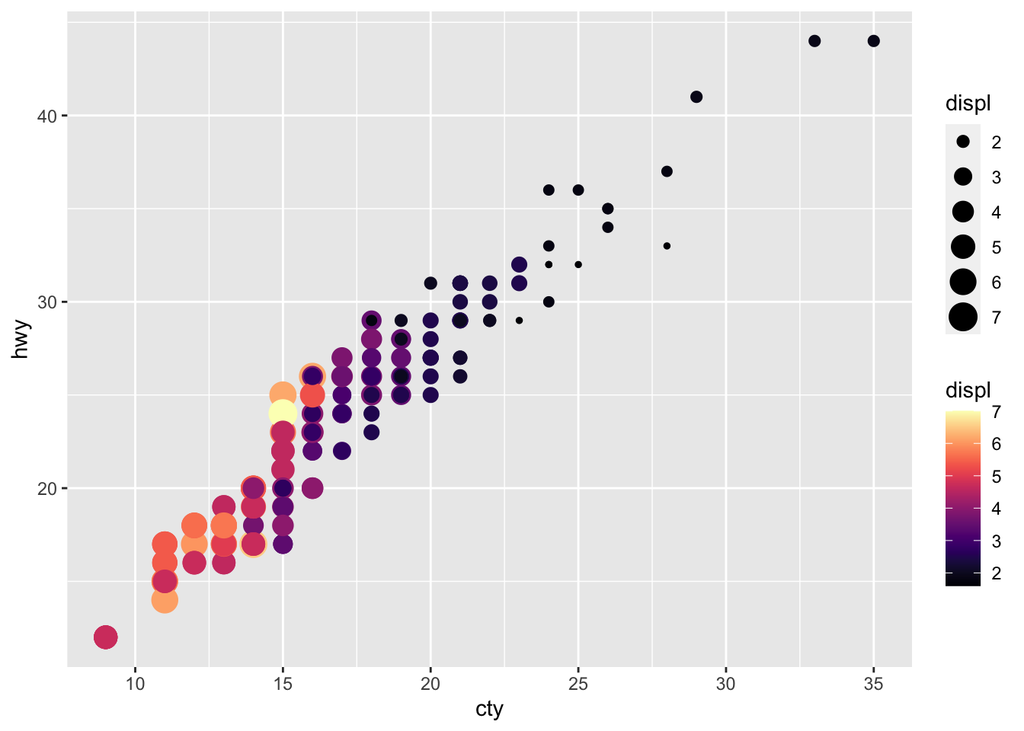

```r
ggplot(mpg, aes(x = cty, y = hwy, color = displ, size = displ)) +
  geom_point() +
  scale_color_viridis(option = "viridis")

ggplot(mpg, aes(x = cty, y = hwy, color = displ, size = displ)) +
  geom_point() +
  scale_color_viridis(option = "magma")
```

Si ninguna de las paletas de colores o gradientes te convence, puedes optar por utilizar tus colores favoritos empleando la función `scale_fill_manual()`. Esta función resulta útil cuando quieres resaltar algún dato importante en los gráficos. Dentro de la función debes indicar, con el argumento values, en un vector los nombres de los colores (nombres o valores hexadecimales)

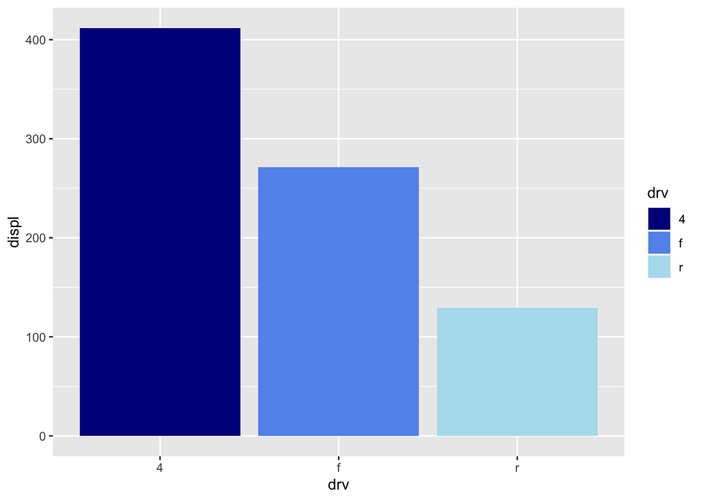

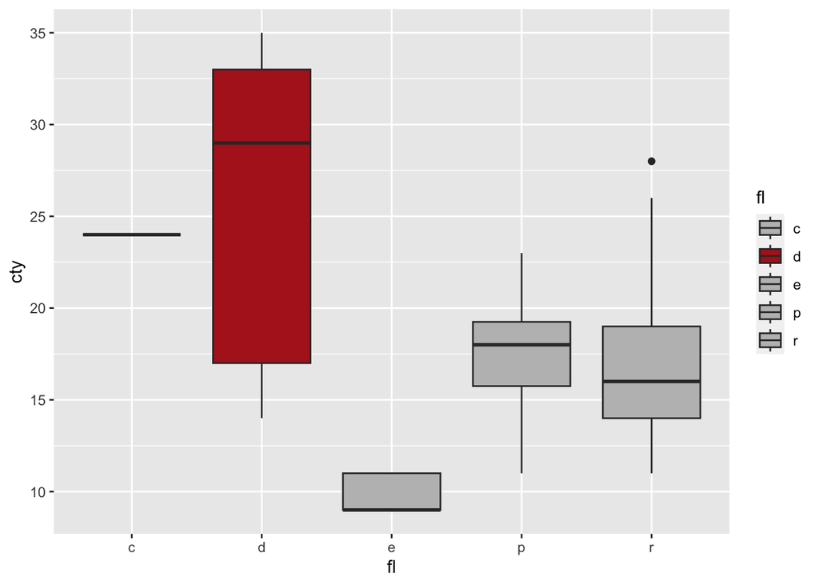

```r
ggplot(mpg, aes(x = drv, y = displ, fill = drv)) +
  geom_bar(stat = "identity") +
  scale_fill_manual(values = c("darkblue", "cornflowerblue", "lightblue2"))

ggplot(mpg, aes(x = fl, y = cty, fill = fl)) +
  geom_boxplot() +
  scale_fill_manual(values = c("gray", "firebrick", "gray", "gray", "gray"))
```

Sin embargo, si requieres descargar más escalas de colores (discretas o contínuas) te recomiendo instalar los paquetes **`ggpubr`** (Kassambara 2023), **`ggsci`**(Xiao 2023) y **`paletteer`** (Hvitfeldt 2021) para crear gráficos con paletas de colores listas para publicaciones:

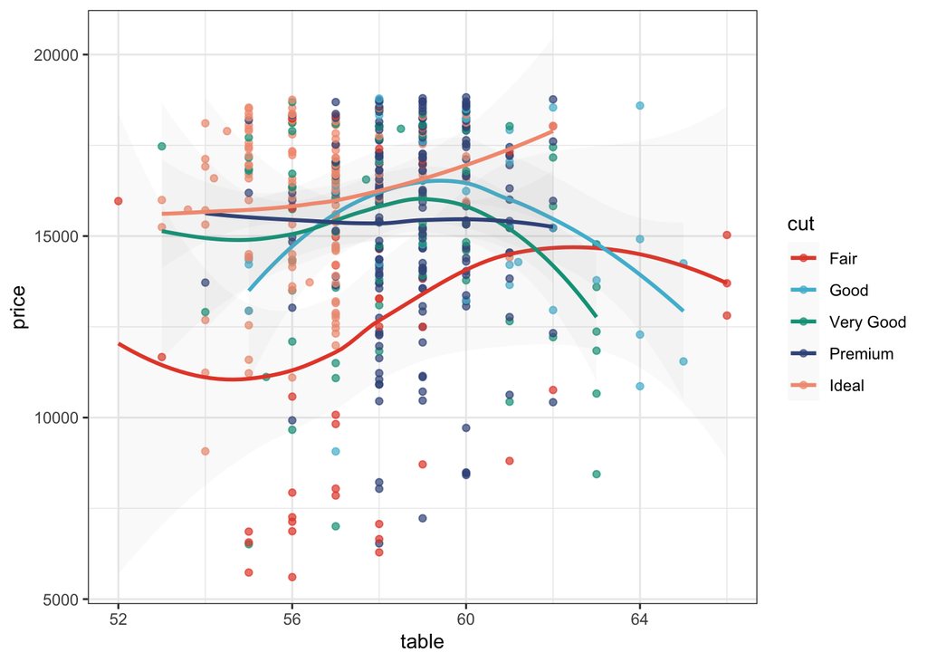

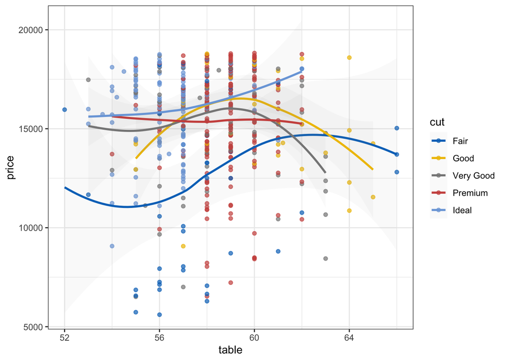

```r
p1 +
  scale_color_npg()
p1 +
  scale_color_jco()
```

# Referencias

Garnier, Simon, Ross, Noam, Rudis, Robert, Camargo, et al. 2023. *viridis(Lite) - Colorblind-Friendly Color Maps for r*. https://doi.org/10.5281/zenodo.4679423.

Hvitfeldt, Emil. 2021. *Paletteer: Comprehensive Collection of Color Palettes*. https://github.com/EmilHvitfeldt/paletteer.

Kassambara, Alboukadel. 2023. *Ggpubr: ’Ggplot2’ Based Publication Ready Plots*. https://CRAN.R-project.org/package=ggpubr.

Neuwirth, Erich. 2022. *RColorBrewer: ColorBrewer Palettes*. https://CRAN.R-project.org/package=RColorBrewer.

Wickham, Hadley. 2016. *Ggplot2: Elegant Graphics for Data Analysis*. Springer-Verlag New York. https://ggplot2.tidyverse.org.

Wickham, Hadley, Mara Averick, Jennifer Bryan, Winston Chang, Lucy McGowan, Romain François, Garrett Grolemund, et al. 2019. “Welcome to the Tidyverse.” *Journal of Open Source Software* 4 (43): 1686. https://doi.org/10.21105/joss.01686.

Xiao, Nan. 2023. *Ggsci: Scientific Journal and Sci-Fi Themed Color Palettes for ’Ggplot2’*. https://CRAN.R-project.org/package=ggsci.